# Homework Assignment3

2023-03-20

## Objective

**Practise using GSEA**

Given the ranked list comparing mesenchymal and immunoreactive ovarian cancer subtypes(mesenchymal genes have positive scores, immunoreactive have negative scores). perform a GSEA preranked analysis using the following parameters:

- mesenchymal vs immuno rank file
- genesets from the baderlab geneset collection from February 1, 2020 containing GO = biological process, no IEA and pathways.
- maximum geneset size of 200
- minimum geneset size of 15
- gene set permutation

## Time managerment

Finished: Mar 21, 2023

Time Estimated: 2 hours

Time Spent: 2 hours

## Results

### Data prepare

For this assignment, we should prepare the ranked gene list from the assignment and genesets from the baderlab geneset collection. I downloaded [mesenchymal vs immuno rank file](https://github.com/bcb420-2020/Student_Wiki/blob/master/MesenvsImmuno_RNASeq_ranks.rnk) and the genesets from the [baderlab geneset](http://download.baderlab.org/EM_Genesets/) collection.The genesets are annotated with Entrez IDs.

I choose clusterProfiler to complete the GSEA analysis.

First of all, we need to library the packages.

```r
if(!require("GSEABase")){
  BiocManager::install("GSEABase")
}
if(!require("clusterProfiler")){
  BiocManager::install("clusterProfiler")
}
if(!require("org.Hs.eg.db")){
  BiocManager::install("org.Hs.eg.db")
}
if(!require("stringr")){
  BiocManager::install("stringr")
}
if(!require("enrichplot")){
  BiocManager::install("enrichplot")
}
```

### ID transform

The gene names of the ranked gene list are Symbol IDs. We should tranform the symbol IDs to Entrez ID.

```r
gene_rank = read.table("./gene_rank.txt", sep = "\t", header = T)
entrez_ids <- AnnotationDbi::select(org.Hs.eg.db, keys = gene_rank$GeneName, columns = "ENTREZID", keytype = "SYMBOL")
entrez_ids = na.omit(entrez_ids)
gene_rank = merge(gene_rank, entrez_ids, by.x = "GeneName", by.y = "SYMBOL")
```

Then we should sort the gene list annotated with Entrez IDs.

```r
# get the gene list
geneList = gene_rank$rank
# rename the gene list with ENTREZ IDs
names(geneList) = gene_rank$ENTREZID
# sort the gene list
geneList = sort(geneList,decreasing = T)
head(geneList)
```

```
##     9543    84168      165    23452     2200     1307
## 36.32958 35.47949 33.19159 32.50876 32.39968 32.00046
```

Then, we load the genesets.

```r
geneset <- read.gmt("./Human_GOBP_AllPathways_no_GO_iea_February_01_2020_entrezgene.gmt")
geneset$term = str_replace(geneset$term,"\\%.*","")
head(geneset)
```

```
##                            term   gene
## 1        PROTEIN CITRULLINATION 353238
## 2        PROTEIN CITRULLINATION  11240
## 3        PROTEIN CITRULLINATION  29943
## 4        PROTEIN CITRULLINATION  51702
## 5        PROTEIN CITRULLINATION  23569
## 6 METHYLGLYOXAL DEGRADATION III    231
```

Now, we could perform the GSEA analysis using the following parameters: - mesenchymal vs immuno rank file - genesets from the baderlab geneset collection from February 1, 2020 containing GO biological process, no IEA and pathways. - maximum geneset size of 200 - minimum geneset size of 15 - gene set permutation

```r
egmt <- GSEA(geneList,
             TERM2GENE=geneset,
             verbose=F,
             minGSSize = 15,
             maxGSSize = 200,
             pvalueCutoff = 0.05,
             pAdjustMethod = "fdr"
             )
results = egmt@result
results$geneNums = unlist(lapply(results$core_enrichment, FUN = function(x){
  return(length(unlist(str_split(x, "/"))))
}))
rownames(results) = 1:nrow(results)
# get the first 6 rows of GSEA results
head(results)
```

```
##                                   ID                        Description setSize
## 1 HALLMARK_INTERFERON_ALPHA_RESPONSE HALLMARK_INTERFERON_ALPHA_RESPONSE      92
## 2 HALLMARK_INTERFERON_GAMMA_RESPONSE HALLMARK_INTERFERON_GAMMA_RESPONSE     194
## 3               HALLMARK_E2F_TARGETS               HALLMARK_E2F_TARGETS     186
## 4               INTERFERON SIGNALING               INTERFERON SIGNALING     168
## 5      MITOCHONDRIAL GENE EXPRESSION      MITOCHONDRIAL GENE EXPRESSION     122
## 6                   SYNTHESIS OF DNA                   SYNTHESIS OF DNA     109
##   enrichmentScore       NES pvalue     p.adjust       qvalue rank
## 1      -0.8624638 -2.966250  1e-10 4.281452e-09 2.739389e-09 1038
## 2      -0.7538687 -2.964172  1e-10 4.281452e-09 2.739389e-09 1215
## 3      -0.6998266 -2.745535  1e-10 4.281452e-09 2.739389e-09 2515
## 4      -0.6983876 -2.693182  1e-10 4.281452e-09 2.739389e-09 1042
## 5      -0.7178244 -2.636397  1e-10 4.281452e-09 2.739389e-09 2790
## 6      -0.7281369 -2.615769  1e-10 4.281452e-09 2.739389e-09 2323
##                     leading_edge
```

[output cut: 20 more lines]

the top 5 gene sets returned for the Mesenchymal subtype:

```r
res_mesenchymal <- results[results$enrichmentScore > 0,]
res_mesenchymal <- res_mesenchymal[order(res_mesenchymal$pvalue, -res_mesenchymal$NES, decreasing = F),]
# export the results
write.csv(res_mesenchymal, file = "GSEA_results_for_Mesenchymal_subtype.csv", quote = F, row.names = FALSE)
head(res_mesenchymal, 5)
```

```
##                                             ID
## 18  HALLMARK_EPITHELIAL_MESENCHYMAL_TRANSITION
## 58                          COLLAGEN FORMATION
## 61                      NABA_ECM_GLYCOPROTEINS
## 69 COLLAGEN BIOSYNTHESIS AND MODIFYING ENZYMES
## 70    BETA1 INTEGRIN CELL SURFACE INTERACTIONS
##                                    Description setSize enrichmentScore      NES
## 18  HALLMARK_EPITHELIAL_MESENCHYMAL_TRANSITION     191       0.8607771 2.568918
## 58                          COLLAGEN FORMATION      73       0.8769097 2.397879
## 61                      NABA_ECM_GLYCOPROTEINS     143       0.8194166 2.386595
## 69 COLLAGEN BIOSYNTHESIS AND MODIFYING ENZYMES      55       0.9018473 2.357475
## 70    BETA1 INTEGRIN CELL SURFACE INTERACTIONS      63       0.8793745 2.355819
##    pvalue     p.adjust       qvalue rank                   leading_edge
## 18  1e-10 4.281452e-09 2.739389e-09  942  tags=57%, list=7%, signal=53%
## 58  1e-10 4.281452e-09 2.739389e-09  827  tags=58%, list=6%, signal=54%
## 61  1e-10 4.281452e-09 2.739389e-09 1390 tags=55%, list=10%, signal=49%
## 69  1e-10 4.281452e-09 2.739389e-09  827  tags=67%, list=6%, signal=63%
## 70  1e-10 4.281452e-09 2.739389e-09  925  tags=62%, list=7%, signal=58%
##                                                                                                                                                                                                                                                                                                          …
## 18 2200/1307/633/1289/6678/1278/7078/4017/800/1277/1842/1293/12…
## 58                                                                                                                                                                                                                                                                                                       …
## 61                                                                                                                                 165/2200/6678/83716/3912/1842/148113/11117/7057/3487/2335/70…
## 69                                                                                                                                                                                                                                                                                                       …
## 70                                                                                                                                                                                                                                                                                                       …
##    geneNums
## 18      108
## 58       42
## 61       78
## 69       37
## 70       39
```

the top gene set returned for the Mesenchymal subtype:

```r
res_mesenchymal[1,]
```

```
##                                            ID
## 18 HALLMARK_EPITHELIAL_MESENCHYMAL_TRANSITION
##                                   Description setSize enrichmentScore      NES
## 18 HALLMARK_EPITHELIAL_MESENCHYMAL_TRANSITION     191       0.8607771 2.568918
##    pvalue     p.adjust       qvalue rank                  leading_edge
## 18  1e-10 4.281452e-09 2.739389e-09  942 tags=57%, list=7%, signal=53%
##                                                                                                                                                                                                                                                                                                          …
## 18 2200/1307/633/1289/6678/1278/7078/4017/800/1277/1842/1293/12…
##    geneNums
## 18      108
```

the top gene associated with the top geneset for the Mesenchymal subtype:

```r
entrez_ids[entrez_ids$ENTREZID == "2200",]
```

```
##   SYMBOL ENTREZID
## 5   FBN1     2200
```

the top 5 gene sets returned for the Immunoreactive subtype:

```r
res_immunoreactive <- results[results$enrichmentScore < 0,]
res_immunoreactive<- res_immunoreactive[order(res_immunoreactive$pvalue, res_immunoreactive$NES, decreasing = F),]
# export the results
write.csv(res_immunoreactive, file = "GSEA_results_for_Immunoreactive_subtype.csv", quote = F, row.names = FALSE)
head(res_immunoreactive, 5)
```

```
##                                   ID                        Description setSize
## 1 HALLMARK_INTERFERON_ALPHA_RESPONSE HALLMARK_INTERFERON_ALPHA_RESPONSE      92
## 2 HALLMARK_INTERFERON_GAMMA_RESPONSE HALLMARK_INTERFERON_GAMMA_RESPONSE     194
## 3               HALLMARK_E2F_TARGETS               HALLMARK_E2F_TARGETS     186
## 4               INTERFERON SIGNALING               INTERFERON SIGNALING     168
## 5      MITOCHONDRIAL GENE EXPRESSION      MITOCHONDRIAL GENE EXPRESSION     122
##   enrichmentScore       NES pvalue     p.adjust       qvalue rank
## 1      -0.8624638 -2.966250  1e-10 4.281452e-09 2.739389e-09 1038
## 2      -0.7538687 -2.964172  1e-10 4.281452e-09 2.739389e-09 1215
## 3      -0.6998266 -2.745535  1e-10 4.281452e-09 2.739389e-09 2515
## 4      -0.6983876 -2.693182  1e-10 4.281452e-09 2.739389e-09 1042
## 5      -0.7178244 -2.636397  1e-10 4.281452e-09 2.739389e-09 2790
##                     leading_edge
## 1  tags=73%, list=8%, signal=68%
## 2  tags=55%, list=9%, signal=50%
## 3 tags=60%, list=19%, signal=49%
## 4  tags=40%, list=8%, signal=37%
## 5 tags=70%, list=21%, signal=56%
##                                                                                                                                                                                                                                                                                                          …
## 1                                                                                                                                                                                                                                       54809/94240/91543/8519/2766/5610/7318/103/55008/81894/23424/…
## 2                                6648/8767/22914/4600/94240/3560/3662/942/91543/5610/3117/259…
## 3 4001/3184/29980/6241/1786/146909/11340/7913/57122/8243/5983/…
## 4                                                                                                                                                                                                                                               3119/3662/10346/91543/8519/5610/3117/7318/25939/103/3838/…
## 5                                                                                55278/54148/64969/54802/124995/55157/25821/26284/51642/90480…
##   geneNums
## 1       67
## 2      106
## 3      111
## 4       67
## 5       86
```

the top gene set returned for the Immunoreactive subtype:

```r
res_immunoreactive[1,]
```

```
##                                   ID                        Description setSize
## 1 HALLMARK_INTERFERON_ALPHA_RESPONSE HALLMARK_INTERFERON_ALPHA_RESPONSE      92
##   enrichmentScore      NES pvalue     p.adjust       qvalue rank
## 1      -0.8624638 -2.96625  1e-10 4.281452e-09 2.739389e-09 1038
##                    leading_edge
## 1 tags=73%, list=8%, signal=68%
##                                                                                                                                                                                                                                                                                                          …
## 1 54809/94240/91543/8519/2766/5610/7318/103/55008/81894/23424/…
##   geneNums
## 1       67
```

the top gene associated with the top geneset for the Immunoreactive subtype:

```r
entrez_ids[entrez_ids$ENTREZID == "54809",]
```

```
##       SYMBOL ENTREZID
## 14011  SAMD9    54809
```

Then we visualize the most significant top5 pathways for mesenchymal and immunoreactive ovarian cancer subtypes(mesenchymal genes have positive scores, immunoreactive have negative scores).

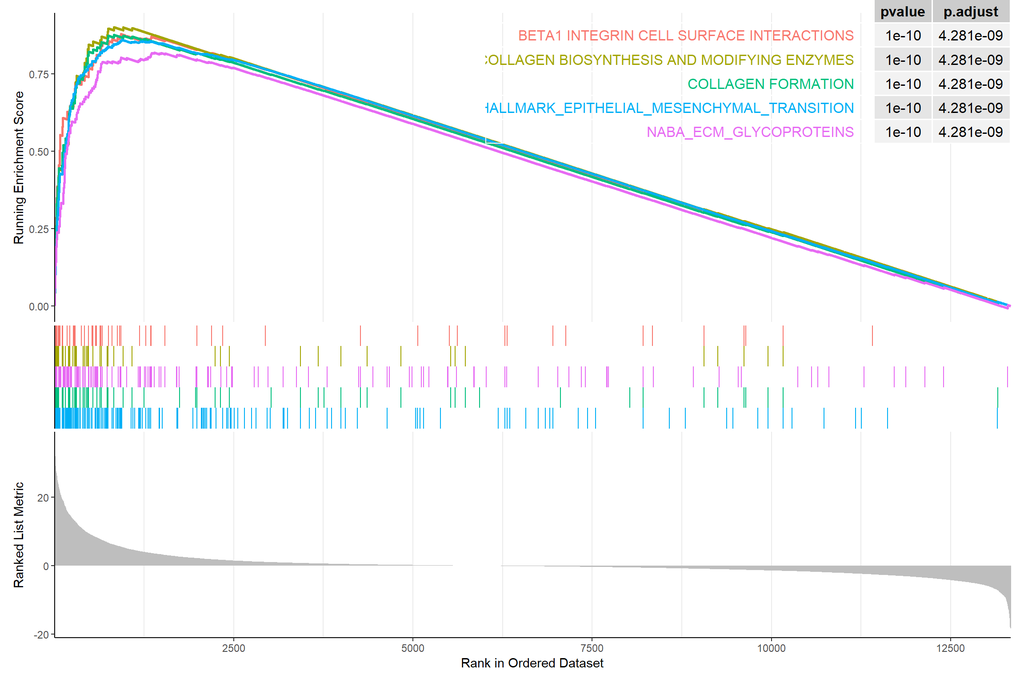

```r
# mesenchymal genes
pathways_mesenchymal = as.numeric(rownames(results)[results$enrichmentScore > 0])[1:5]
gseaplot2(egmt, geneSetID = pathways_mesenchymal,pvalue_table = T)
```

<Figure 1 the top 5 gene set returned for the Mesenchymal subtype >

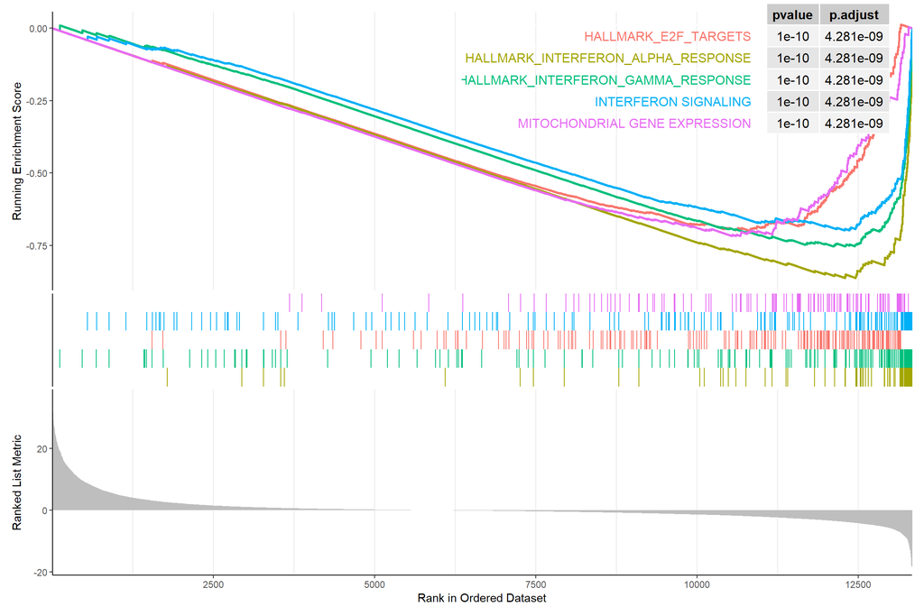

```r
# immunoreactive genes
pathways_immunoreactive = as.numeric(rownames(results)[results$enrichmentScore < 0])[1:5]
gseaplot2(egmt, geneSetID = pathways_immunoreactive,pvalue_table = T)
```

<Figure 2 the top 5 gene set returned for the Immunoreactive subtype >

## Interpretation

**1.Explain the reasons for using each of the above parameters.**

GSEA is used to evaluate the distribution trend of a predefined gene set in a gene table that is sorted by its correlation with a phenotype, in order to determine its contribution to the phenotype. The input data consists of two parts: a gene set with known functions (which can be GO annotations, MsigDB annotations, or other gene set definitions in the appropriate format) and an expression matrix (which can also be a sorted list). GSEA sorts the genes in the gene set according to their correlation with the phenotype (which can be understood as the change in expression values), and then determines whether the genes in each annotation of the gene set are enriched in the upper or lower part of the gene table sorted by phenotype correlation. This allows GSEA to determine the impact of coordinated changes in genes within the gene set on the phenotype.

The reasons for using each of the above parameters:

- Mesenchymal vs. immuno rank file: This parameter specifies the ranked list of genes that will be used for the GSEA analysis. In this case, the list compares mesenchymal and immunoreactive ovarian cancer subtypes, where mesenchymal genes have positive scores and immunoreactive genes have negative scores.
- Genesets from the Baderlab geneset collection from February 1, 2020 containing GO biological process, no IEA and pathways: This parameter specifies the gene sets that will be used for the GSEA analysis. The Baderlab geneset collection is a curated database of gene sets that includes GO biological process and pathway gene sets. The “no IEA” filter ensures that only experimentally validated gene sets are used in the analysis.
- Maximum geneset size of 200: This parameter specifies the maximum number of genes allowed in a gene set. It is set to 200 in this analysis, which means that any gene set with more than 200 genes will be excluded.
- Minimum geneset size of 15: This parameter specifies the minimum number of genes allowed in a gene set. It is set to 15 in this analysis, which means that any gene set with fewer than 15 genes will be excluded.
- Gene set permutation: This parameter specifies the method used to calculate the statistical significance of the enrichment score for each gene set. Gene set permutation is a widely used method that randomly shuffles gene labels to generate a null distribution of enrichment scores. The actual enrichment score is then compared to this null distribution to calculate a p-value.

**2. What is the top gene set returned for the Mesenchymal sub type? What is the top gene set returned for the Immunoreactive subtype? For each of the genesets answer the below questions:**

- **What is its pvalue, ES, NES and FDR associated with it.**
- **How many genes in its leading edge?**
- **What is the top gene associated with this geneset.**

The top gene set returned for the Mesenchymal subtype is HALLMARK_EPITHELIAL_MESENCHYMAL_TRANSITION:

pvalue: 1e-10

ES: 0.8607771

FDR: 4.281452e-09

There are 108 genes in its leading edge.

The top gene associated with this geneset is FBN1(Entrez ID:2200).

The top gene set returned for the Immunoreactive subtype is HALLMARK_INTERFERON_ALPHA_RESPONSE :

pvalue: 1e-10

ES: -0.8624638

FDR: 4.281452e-09

There are 67 genes in its leading edge.

The top gene associated with this geneset is SAMD9(Entrez ID:54809).

## Reference

- Subramanian, A., Tamayo, P., Mootha, V. K., Mukherjee, S., Ebert, B. L., Gillette, M. A., … & Mesirov, J. P. (2005). Gene set enrichment analysis: a knowledge-based approach for interpreting genome-wide expression profiles. Proceedings of the National Academy of Sciences, 102(43), 15545-15550.
- Yu, G., Wang, L. G., Han, Y., & He, Q. Y. (2012). clusterProfiler: an R package for comparing biological themes among gene clusters. Omics: a journal of integrative biology, 16(5), 284-287.